# SGG - All of things for the manuscript

André Soares

14 January 2019

**Basic stuff:**

- Library sizes:

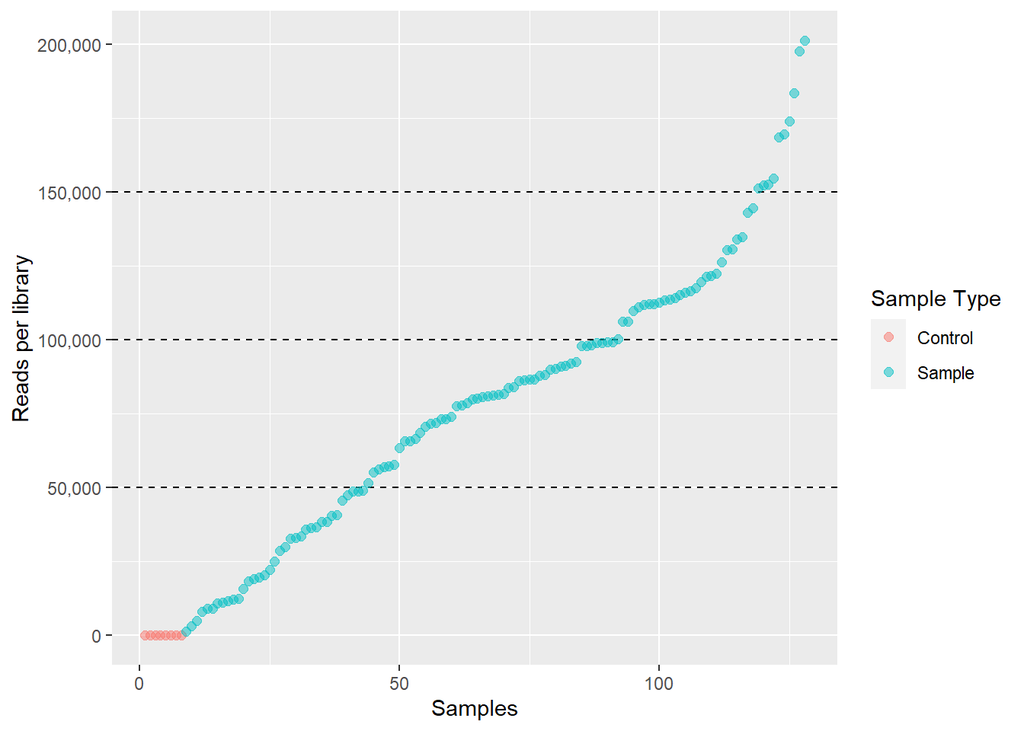

- Number of samples:

```
## [1] 128
```

- Number of true contaminants found by `decontam` in the full dataset by prevalence:

```
##
## FALSE  TRUE
## 70934     3
```

- How prevalent are these contaminants throught the dataset?

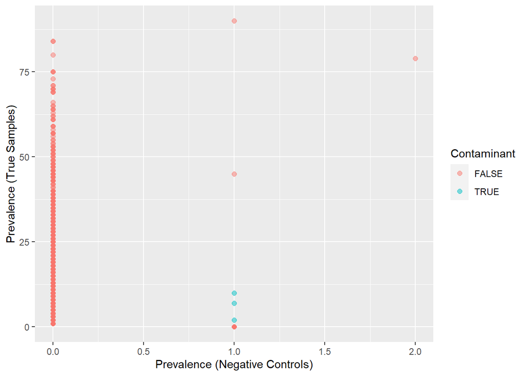

How many reads are associated to these contaminants?

```
## [1] 826
```

These SVs were removed for the ensuing analyses

- Number of samples without controls, Taff’s Well:

```
## [1] 117
```

- Number of SVs:

```
## [1] 69956
```

- Number of trimmed quality filtered reads:

```
## [1] 9656492
```

- Total numbers following SV generation:

```
##     P3     P4     S2     S1     P1     S4     S3     P2     64     68    120
##      0      0      0     41    124    151    211    215   1416   3079   4922
##     29     91     28    118     66     33     30    119     65     80     14
##   8062   9073   9178  10884  11158  11711  12330  12477  15850  18519  19069
##     77      5    105     12     46     75     56     54    114      7      4
##  19637  20403  22229  25007  28773  30103  32907  32992  33533  35910  36319
##     83     20     69      6     55     61     67     58     19     31    106
##  36600  38368  38608  40598  40774  45663  47456  48693  48702  48945  51724
##     15     62    100     53     60     22     11     51     92     57     63
##  55301  56335  57092  57230  57786  63535  65801  65873  66521  68756  70747
##     43     94    101    102     45      3      1    110     87     13      9
##  71612  72036  73237  73344  74010  77587  77925  78713  80100  80111  80657
##     41    113     36     37      8     97    112     39     18     23    115
##  81129  81145  81561  81786  83949  84001  86245  86541  86579  86771  88077
##     78     90     16     52     59     81     74     25     98     85     21
##  88237  89950  90410  90959  91331  92038  92613  97993  98032  98146  98949
##      2     40     10     49     72     50     26     70     27     93     79
##  99012  99346  99364 100428 106152 106185 109837 111149 111962 112231 112293
##     96     35     82     47     42     17     48     88     38     71    111
## 112626 113375 113792 114329 115386 116052 116551 117609 119558 121495 121623
##     44     89    104     95    117    107     24     99     86     84     76
## 122586 126467 130456 130687 134008 134948 143019 144617 151422 152507 152601
##    116     32    103    108     73     34    109
## 154693 168745 169643 174101 183466 197703 201303
```

- Total numbers following `decontam` and filtering:

```
##     64     68    120     29     91     28    118     66     33     30    119
##   1416   3079   4922   8062   9071   9178  10884  11158  11711  12330  12477
##     65     80     14     77      5    105     12     46     56     54    114
##  15850  18514  19044  19626  20396  22222  24999  28773  32907  32970  33533
##      7      4     83     20     69      6     55     61     67     19     58
##  35910  36316  36568  38350  38608  40598  40767  45663  47456  48682  48693
##     31    106     15     62    100     53     60     22     11     51     92
##  48913  51724  55229  56335  57073  57172  57786  63535  65666  65806  66441
##     57     63     43     94    101    102     45      3      1    110     13
##  68739  70740  71607  71914  73229  73329  74000  77576  77914  78643  80022
##     87      9     41    113     36     37      8     97    112     18     39
##  80086  80649  81089  81141  81561  81770  83946  84001  86229  86506  86538
##     23    115     78     90     16     52     59     81     25     98     85
##  86771  88077  88152  89939  90317  90890  91331  91993  97969  97997  98100
##     21      2     10     40     49     50     72     26     70     27     93
##  98882  98979  99120  99237 100253 105968 106053 109799 111085 111907 111911
##     79     96     35     82     47     42     17     48     88     38     71
## 112203 112460 113273 113688 114311 115356 115969 116538 117589 119517 121495
##    111     44     89    104     95    117    107     24     99     86     84
## 121596 122536 126464 130410 130446 134008 134933 143019 144544 151405 152455
##     76    116     32    103    108     34    109
## 152522 154691 168709 169545 174077 197582 201179
```

- Total numbers of Bacterial SV’s and reads:

```
## [1] 66079
```

[output not shown]

- Total numbers of Archaeal SV’s and reads:

```
## [1] 3877
```

```
## [1] 135209
```

```
##  [1] "Candidatus_Methanoperedens"    "Candidatus_Nitrosoarchaeum"
##  [3] "Methanoregula"                 "Methanobacterium"
##  [5] "Candidatus_Nitrosotenuis"      "Candidatus_Nitrosotalea"
##  [7] "Methanosaeta"                  "Methanocella"
##  [9] "Salarchaeum"                   "Candidatus_Methanofastidiosum"
```

- Batch effect much? (Student’s t-test)

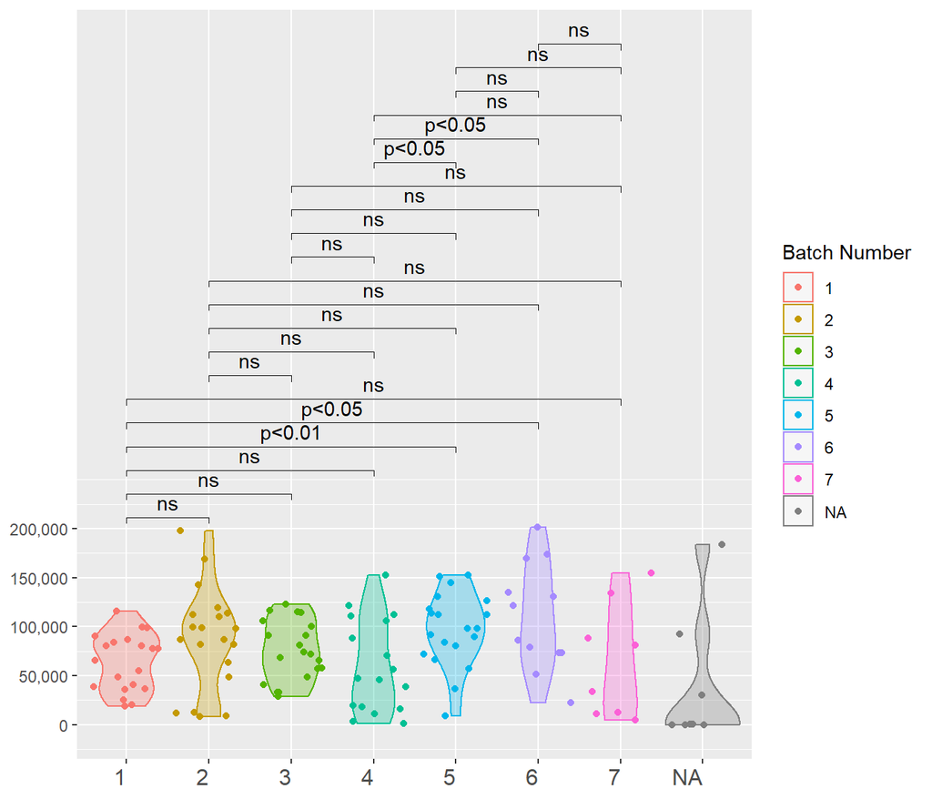

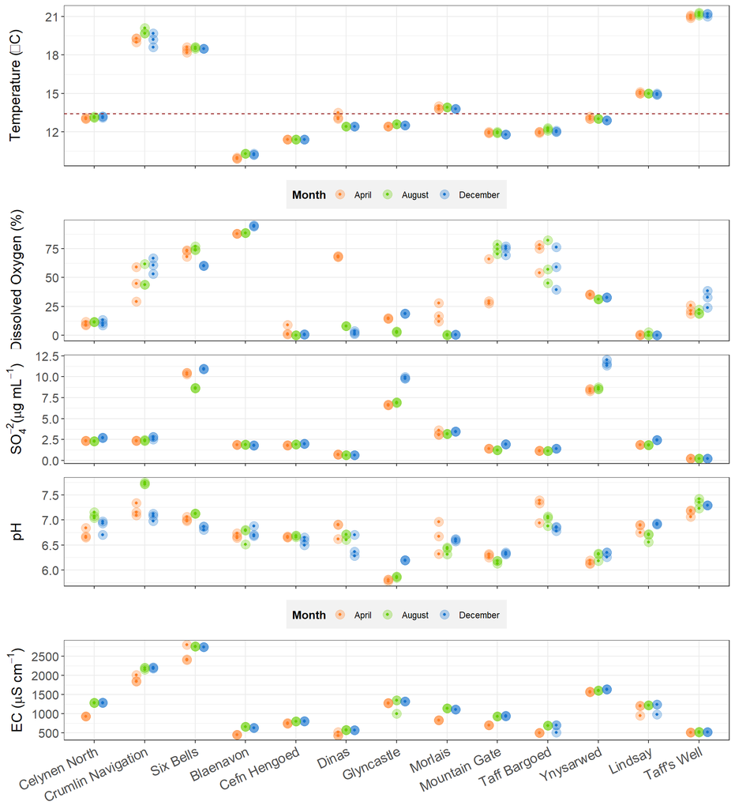

```r
plot_grid(temp_table.plot, do.plot, so4.plot, pH.plot, ec.plot,
          ncol = 1, align='v',
          rel_heights = c(1.75,1.1,1,1,1.75))
```

###**Figure 2a:** High-level taxonomic view of the dataset:

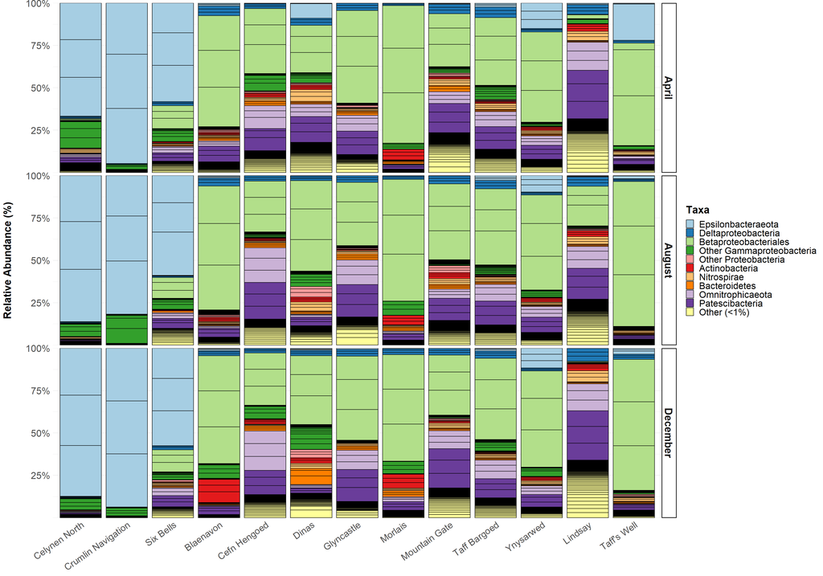

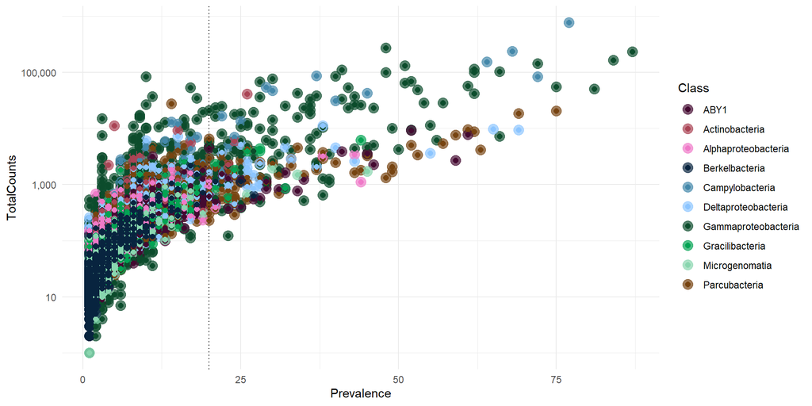

(Omnitrophicaeota and Nitrospira classes not in the top 10 classes)

###**?Figure 2b:** nMDS.

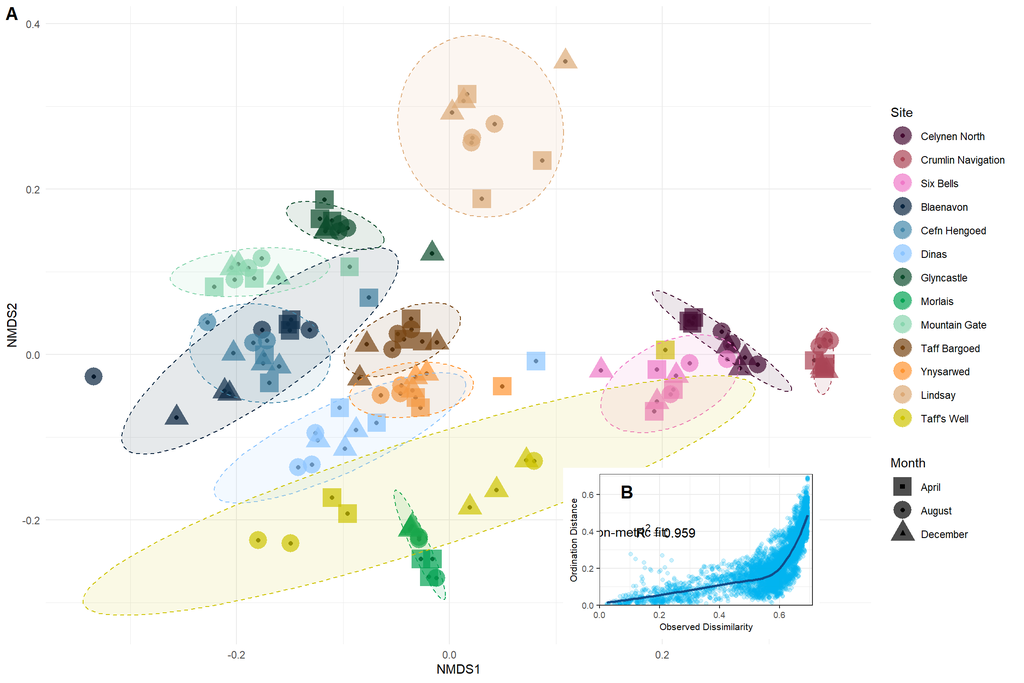

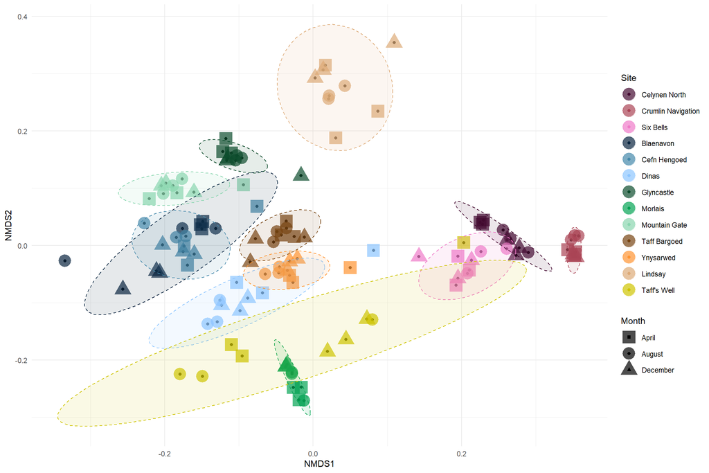

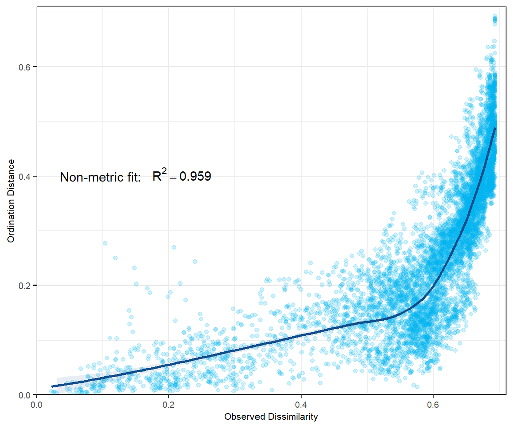

###**?Figure 2b:** CAP with normalised metadata variables, groups highlighted.

Which metadata variables explains the most microbial community structure in this dataset? adonis ~ PERMANOVA (http://cc.oulu.fi/~jarioksa/softhelp/vegan/html/adonis.html) (Working only with variables measured for all samples)

```
##
## Call:
## adonis(formula = ps_jsd ~ Site.name + Pond_L + Month + Batch +      Temp.C + pH + EC.uS.cm + Ca + DO + Mg + K + Na + Cl + NO3 +      X6_Li + X7_Li + X7_Li_He + X9_Be + X11_B + X27_Al + X45_Sc +      X47_Ti_ + X51_V_He + X52_Cr_He + X55_Mn + X56_Fe_He + X59_Co +      X60_Ni + X63_Cu + X68_Zn + X65…
##
## Blocks:  strata
## Permutation: free
## Number of permutations: 1000
##
## Terms added sequentially (first to last)
##
##            Df SumsOfSqs MeanSqs F.Model      R2   Pr(>F)
## Site.name  12   17.2138 1.43448  58.779 0.82994 0.000999 ***
## Month       2    0.1810 0.09049   3.708 0.00873 0.000999 ***
## Batch       1    0.0461 0.04605   1.887 0.00222 0.045954 *
## Temp.C      1    0.1223 0.12233   5.013 0.00590 0.000999 ***
## pH          1    0.0401 0.04005   1.641 0.00193 0.055944 .
## EC.uS.cm    1    0.0526 0.05259   2.155 0.00254 0.022977 *
## Ca          1    0.0450 0.04498   1.843 0.00217 0.041958 *
## DO          1    0.0990 0.09903   4.058 0.00477 0.000999 ***
## Mg          1    0.0612 0.06122   2.509 0.00295 0.009990 **
## K           1    0.0329 0.03289   1.348 0.00159 0.187812
## Na          1    0.0390 0.03896   1.596 0.00188 0.098901 .
## Cl          1    0.1043 0.10432   4.274 0.00503 0.000999 ***
## NO3         1    0.0283 0.02835   1.162 0.00137 0.284715
## X6_Li       1    0.0532 0.05323   2.181 0.00257 0.014985 *
## X7_Li       1    0.0339 0.03394   1.391 0.00164 0.146853
## X7_Li_He    1    0.0282 0.02817   1.154 0.00136 0.289710
## X9_Be       1    0.0207 0.02069   0.848 0.00100 0.603397
## X11_B       1    0.0184 0.01842   0.755 0.00089 0.709291
## X27_Al      1    0.0787 0.07868   3.224 0.00379 0.003996 **
## X45_Sc      1    0.0393 0.03932   1.611 0.00190 0.091908 .
## X47_Ti_     1    0.1232 0.12316   5.047 0.00594 0.000999 ***
## X51_V_He    1    0.0433 0.04334   1.776 0.00209 0.066933 .
## X52_Cr_He   1    0.0079 0.00786   0.322 0.00038 0.985015
## X55_Mn      1    0.0543 0.05435   2.227 0.00262 0.025974 *
## X56_Fe_He   1    0.0402 0.04017   1.646 0.00194 0.087912 .
## X59_Co      1    0.0360 0.03600   1.475 0.00174 0.127872
## X60_Ni      1    0.0455 0.04547   1.863 0.00219 0.056943 .
## X63_Cu      1    0.0188 0.01882   0.771 0.00091 0.656344
## X68_Zn      1    0.0351 0.03513   1.439 0.00169 0.102897
```

[output cut: 31 more lines]

```
## X181_Ta     1    0.0211 0.02115   0.867 0.00102 0.579421
## X182_W      1    0.0304 0.03040   1.246 0.00147 0.238761
## X200_Hg     1    0.0249 0.02487   1.019 0.00120 0.382617
## X201_Hg     1    0.0296 0.02959   1.212 0.00143 0.279720
## X202_Hg     1    0.0195 0.01955   0.801 0.00094 0.550450
## X205_Tl     1    0.0355 0.03547   1.454 0.00171 0.154845
## X206_Pb     1    0.0217 0.02171   0.889 0.00105 0.535465
## X207_Pb     1    0.0275 0.02752   1.128 0.00133 0.331668
## X209_Bi     1    0.0208 0.02080   0.852 0.00100 0.569431
## X232_Th     1    0.0265 0.02650   1.086 0.00128 0.353646
## X238_U      1    0.0240 0.02399   0.983 0.00116 0.458541
## Residuals  33    0.8054 0.02440         0.03883
## Total     116   20.7410                 1.00000
## ---
## Signif. codes:  0 '***' 0.001 '**' 0.01 '*' 0.05 '.' 0.1 ' ' 1
```

```
##
## Call:
## adonis(formula = ps_jsd ~ Pond_L + Month + Temp.C + pH + EC.uS.cm +      Ca + DO + Mg + K + Na + Cl + NO3 + X11_B, data = sampledf,      permutations = 1000, strata = sampledf$Time_point)
##
## Blocks:  strata
## Permutation: free
## Number of permutations: 1000
##
## Terms added sequentially (first to last)
##
##            Df SumsOfSqs MeanSqs F.Model      R2   Pr(>F)
## Pond_L      8   14.1192 1.76490  52.748 0.68074 0.000999 ***
## Month       2    0.1810 0.09049   2.705 0.00873 0.001998 **
## Temp.C      1    0.5549 0.55491  16.585 0.02675 0.000999 ***
## pH          1    0.3324 0.33242   9.935 0.01603 0.000999 ***
## EC.uS.cm    1    0.2443 0.24432   7.302 0.01178 0.000999 ***
## Ca          1    0.5627 0.56269  16.817 0.02713 0.000999 ***
## DO          1    0.4833 0.48334  14.446 0.02330 0.000999 ***
## Mg          1    0.1760 0.17596   5.259 0.00848 0.000999 ***
## K           1    0.4409 0.44091  13.178 0.02126 0.000999 ***
## Na          1    0.1023 0.10233   3.058 0.00493 0.002997 **
## Cl          1    0.2385 0.23851   7.129 0.01150 0.000999 ***
## NO3         1    0.0361 0.03611   1.079 0.00174 0.371628
## X11_B       1    0.0907 0.09073   2.712 0.00437 0.007992 **
## Residuals  95    3.1786 0.03346         0.15325
## Total     116   20.7410                 1.00000
## ---
## Signif. codes:  0 '***' 0.001 '**' 0.01 '*' 0.05 '.' 0.1 ' ' 1
```

i.e. 82.99% of the variation in the dataset is explained by site (p<0.001).

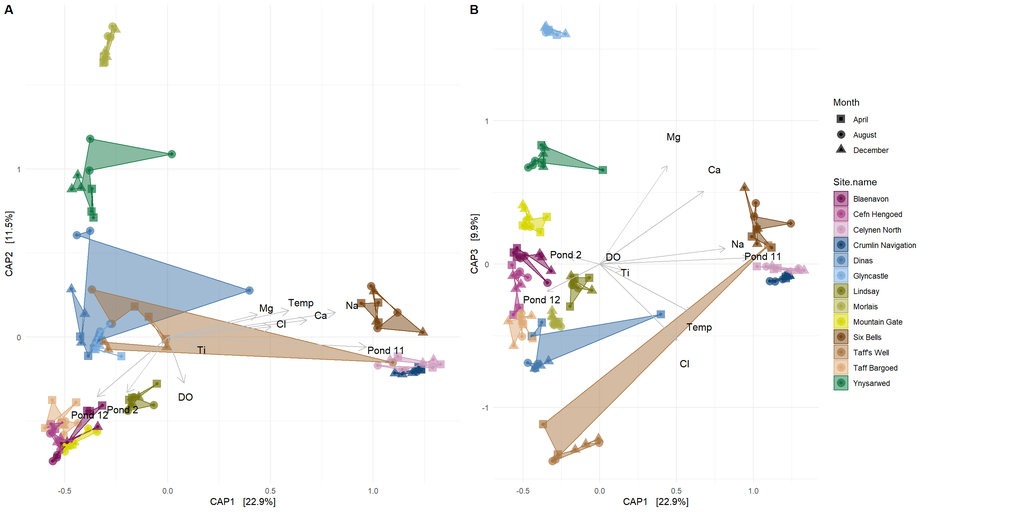

```
## Call: capscale(formula = distance ~ Pond_L + Month + Temp.C + DO + Cl +
## Na + Ca + Mg + X47_Ti_, data = data, k = 3, trymax = 1000, weighted =
## TRUE)
##
##                Inertia Proportion Rank
## Total         20.74121    1.00000
## Constrained   17.10002    0.82445   17
## Unconstrained  3.89582    0.18783   91
## Imaginary     -0.25463   -0.01228   25
## Inertia is squared Unknown distance
##
## Eigenvalues for constrained axes:
##  CAP1  CAP2  CAP3  CAP4  CAP5  CAP6  CAP7  CAP8  CAP9 CAP10 CAP11 CAP12 CAP13
## 4.803 2.413 2.073 1.714 1.430 0.992 0.934 0.799 0.676 0.537 0.321 0.148 0.100
## CAP14 CAP15 CAP16 CAP17
## 0.063 0.042 0.033 0.024
##
## Eigenvalues for unconstrained axes:
##   MDS1   MDS2   MDS3   MDS4   MDS5   MDS6   MDS7   MDS8
## 0.6405 0.3923 0.2191 0.2051 0.1744 0.1481 0.1323 0.1200
## (Showing 8 of 91 unconstrained eigenvalues)
```

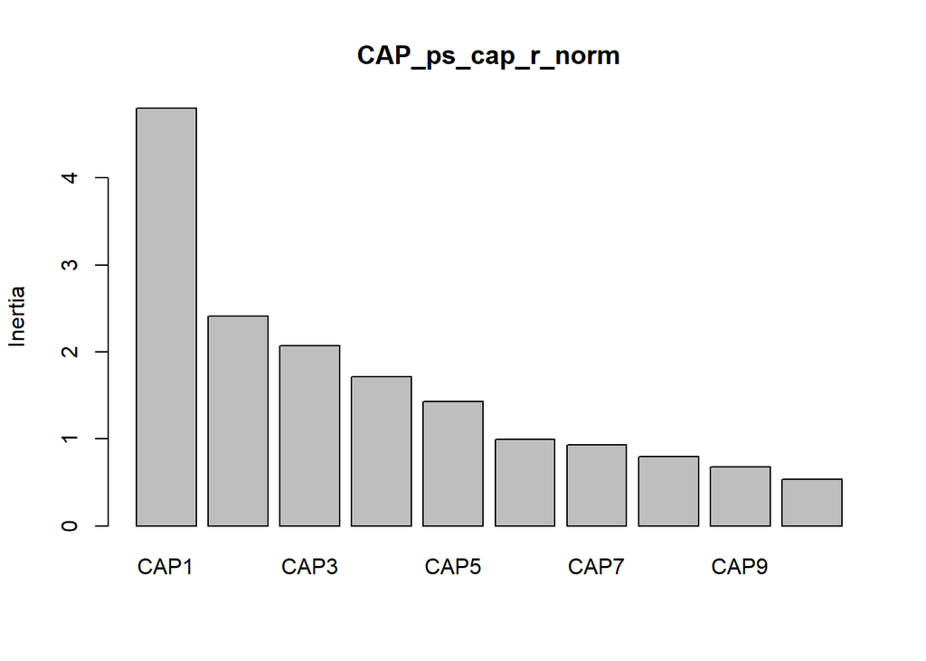

```
## Permutation test for capscale under reduced model
## Forward tests for axes
## Permutation: free
## Number of permutations: 999
##
## Model: capscale(formula = distance ~ Pond_L + Month + Temp.C + DO + Cl + Na + Ca + Mg + X47_Ti_, data = data, k = 3, trymax = 1000, weighted = TRUE)
##          Df SumOfSqs        F Pr(>F)
## CAP1      1   4.8027 122.0447  0.001 ***
## CAP2      1   2.4134  61.3301  0.001 ***
## CAP3      1   2.0725  52.6674  0.001 ***
## CAP4      1   1.7137  43.5474  0.001 ***
## CAP5      1   1.4303  36.3476  0.001 ***
## CAP6      1   0.9924  25.2180  0.001 ***
## CAP7      1   0.9335  23.7225  0.001 ***
## CAP8      1   0.7992  20.3086  0.001 ***
## CAP9      1   0.6763  17.1871  0.001 ***
## CAP10     1   0.5371  13.6491  0.001 ***
## CAP11     1   0.3206   8.1481  0.001 ***
## CAP12     1   0.1475   3.7494  0.005 **
## CAP13     1   0.0996   2.5315  0.078 .
## CAP14     1   0.0627   1.5930  0.487
## CAP15     1   0.0420   1.0668  0.853
## CAP16     1   0.0326   0.8284  0.912
## CAP17     1   0.0238   0.6038  0.949
## Residual 99   3.8958
## ---
## Signif. codes:  0 '***' 0.001 '**' 0.01 '*' 0.05 '.' 0.1 ' ' 1
```

```
## Permutation test for capscale under reduced model
## Terms added sequentially (first to last)
## Permutation: free
## Number of permutations: 999
##
## Model: capscale(formula = distance ~ Pond_L + Month + Temp.C + DO + Cl + Na + Ca + Mg + X47_Ti_, data = data, k = 3, trymax = 1000, weighted = TRUE)
##          Df SumOfSqs       F Pr(>F)
## Pond_L    8  14.1225 44.8599  0.001 ***
## Month     2   0.1849  2.3488  0.003 **
## Temp.C    1   0.5705 14.4964  0.001 ***
## DO        1   0.7734 19.6542  0.001 ***
## Cl        1   0.4243 10.7818  0.001 ***
## Na        1   0.2136  5.4278  0.001 ***
## Ca        1   0.4969 12.6276  0.001 ***
## Mg        1   0.1061  2.6952  0.006 **
## X47_Ti_   1   0.2079  5.2842  0.001 ***
## Residual 99   3.8958
## ---
## Signif. codes:  0 '***' 0.001 '**' 0.01 '*' 0.05 '.' 0.1 ' ' 1
```

*“The test statistic is ``pseudo-F’’, which is the ratio of constrained and unconstrained total Inertia (Chi-squares, variances or something similar), each divided by their respective ranks.”* - http://cc.oulu.fi/~jarioksa/softhelp/vegan/html/anova.cca.html

Do diversity, richness or dominance predict the seen groupings of samples?

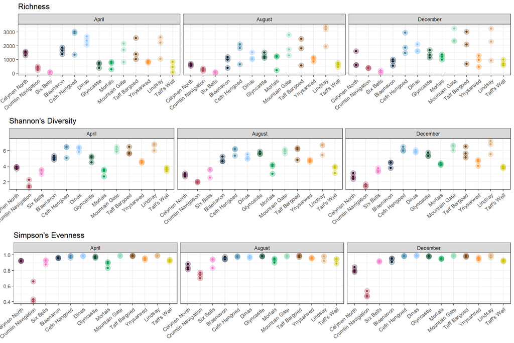

Not at the site level, but how about if we divide them into the groups of samples we’ve seen for the `CAP`?

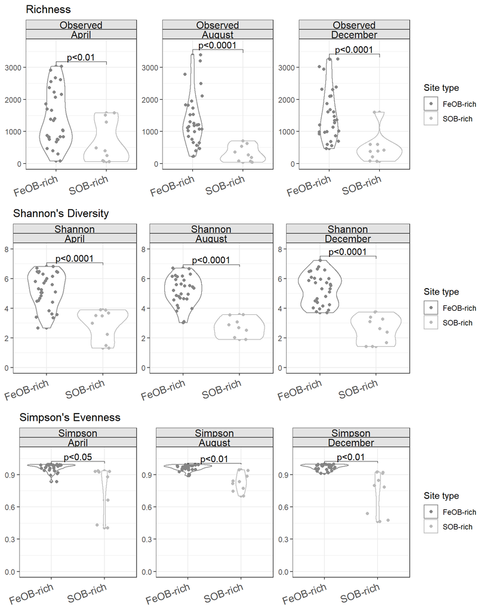

Does seasonality affect Beta- or Epsilonproteobacteria relative abundances?

###**Figure 3:** Genus-level view of the dataset per month and site:

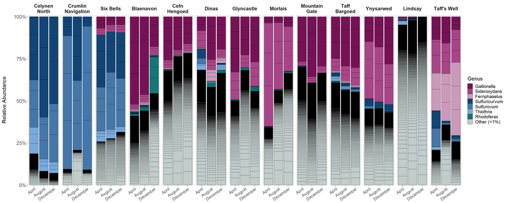

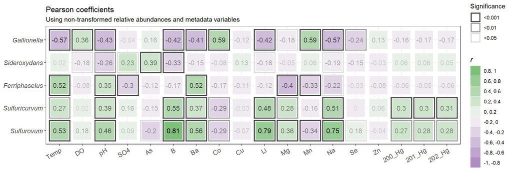